# Investigation of housing prices in the Seattle area

# Introduction

This project delves into predicting the cost of houses in the Seattle housing area. With a shared dataset, I embarked on exploring various models to forecast housing prices based on specific variables. In order to create these models, careful consideration was given to selecting the most relevant variables, and diagnostic plots were employed to assess the models’ appropriateness.

Drawing insights from articles like “5 factors that affect a home’s value,” I focused on investigating the impact of location, home size, age, and renovations on housing prices in the Seattle area. By examining the provided data, I aimed to uncover the true influence of these factors on housing prices.

To tackle this task, I leveraged Multiple Linear Regression, which enabled the creation of several models. Additionally, I used diagnostic plots to ensure the models’ validity. An intriguing aspect was observing how the complexity of the models affected the $r^2$ value. Balancing complexity and predictive power, I made thoughtful decisions regarding the number of factors to include in each multiple linear regression model.

Through this personal project, I aimed to gain valuable insights into the housing market dynamics in Seattle and provide a reliable method for predicting housing costs in the area.

# Data Investigation & Cleaning

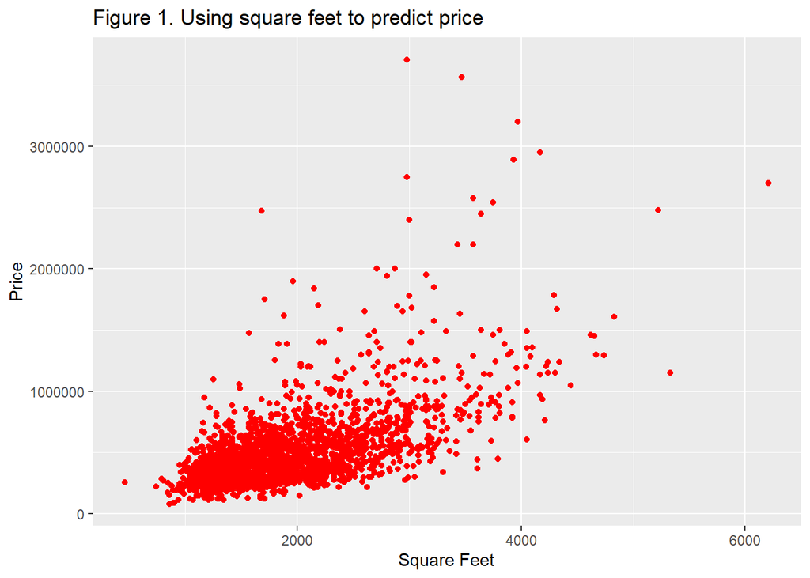

```r
library(tidyverse)
library(GGally)
options(scipen = 999)
housing <- read.csv(file.choose())

housing1 <- housing %>%
  select(price, bedrooms, bathrooms, sqft_living15, floors, waterfront, view, condition, grade, yr_built, yr_renovated, lat, long)

house2 <- housing1 %>%
  mutate(Waterfront = ifelse(waterfront == TRUE, 1, 0),
         recentlyRenovated = ifelse(yr_renovated > 2010, 1, 0),
         familyHome = ifelse(bedrooms > 3, 1, 0)) %>%
  select(-waterfront, yr_renovated)

ggplot(data = house2, aes(x = sqft_living15, y = price)) +
  geom_point(color = "red") +
  labs(title = "Figure 1. Using square feet to predict price", y = "Price", x ="Square Feet" )
```

Figure 1

This model is a simple graph to see if Square Feet can be used to predict the price of the homes. It seems like there could be some trend but way there are too many outliers on this graph.

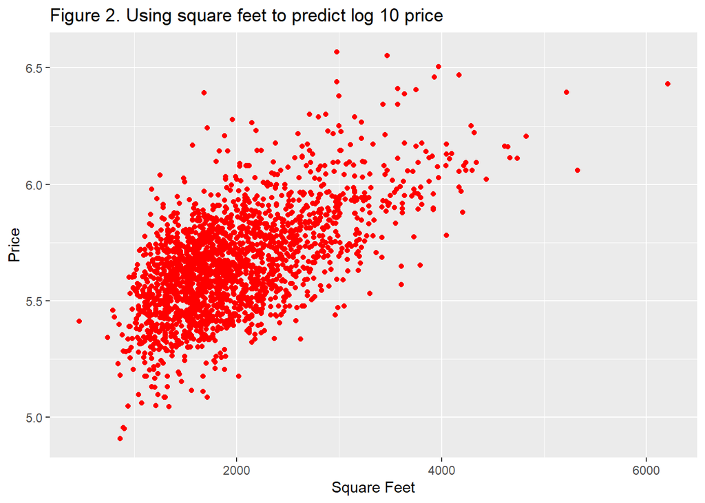

```r
ggplot(data = house2, aes(x = sqft_living15, y = log10(price))) +
  geom_point(color = "red") +
  labs(title = "Figure 2. Using square feet to predict log 10 price", y = "Price", x ="Square Feet" )
```

Figure 2

This model takes the log10 of the price and plots the square feet. As you can see there seems to be a much better trend this way. May be worth investigating.

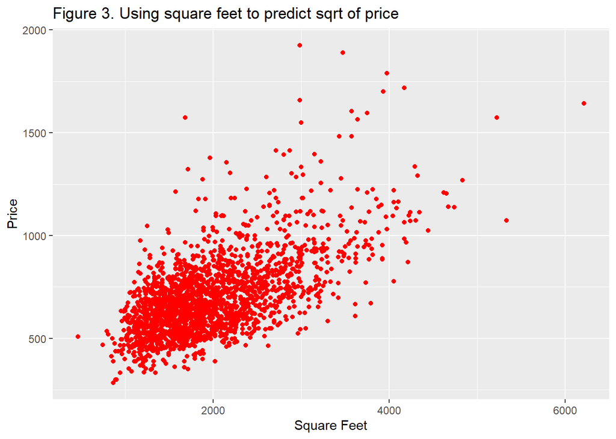

```r
ggplot(data = house2, aes(x = sqft_living15, y = sqrt(price))) +
  geom_point(color = "red") +
  labs(title = "Figure 3. Using square feet to predict sqrt of price", y = "Price", x ="Square Feet" )
```

Figure 3

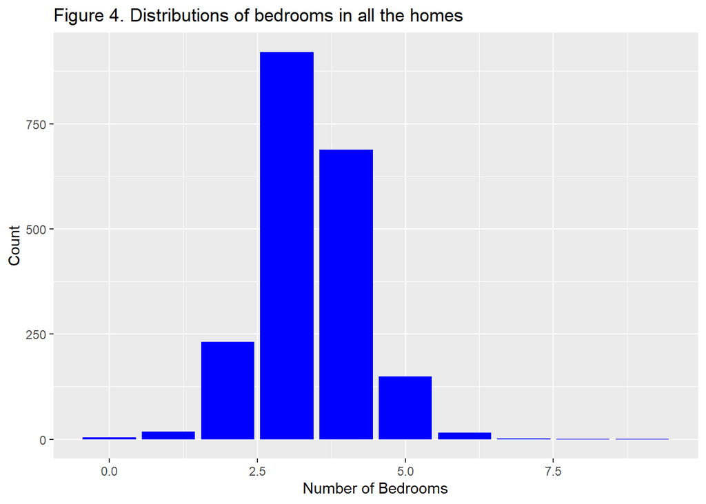

```r
ggplot(data = house2, aes(x = bedrooms)) +
  geom_bar(fill = "blue") +
  labs(title = "Figure 4. Distributions of bedrooms in all the homes", x = "Number of Bedrooms", y = "Count")
```

Figure 4

This plot shows the count of bedrooms in each home. We can see that this distribution looks somewhat normal.I created this plot to see where the median would probably be. Here we can see that 3 bedroom homes are the most common.

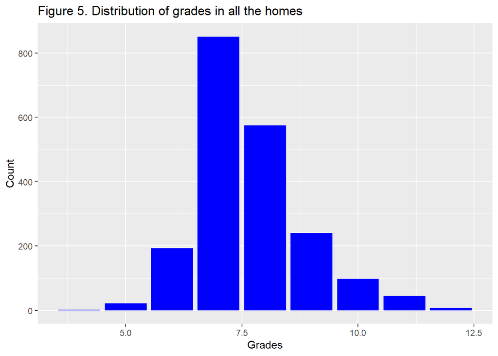

```r
ggplot(data = house2, aes(x = grade)) +
  geom_bar(fill = "blue") +
  labs(title = "Figure 5. Distribution of grades in all the homes", x = "Grades", y = "Count")
```

Figure 5

Here I did a similar graph to figure four but with the grades of each home. 7 is the most common grade with 8 coming in second.

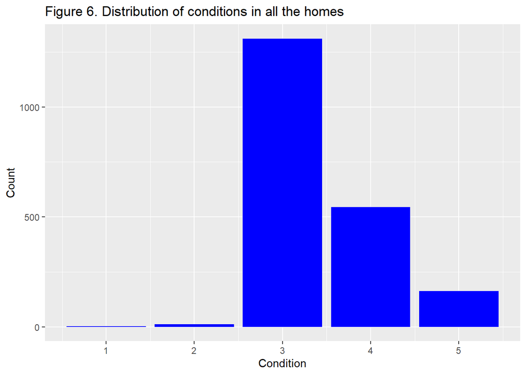

```r
ggplot(data = house2, aes(x = condition)) +
  geom_bar(fill = "blue") +
  labs(title = "Figure 6. Distribution of conditions in all the homes", x = "Condition", y = "Count")
```

Figure 6

This graph is similar to the previous two but with condition instead. 3 is the most common by far and 1 and 2 seem almost non existent.

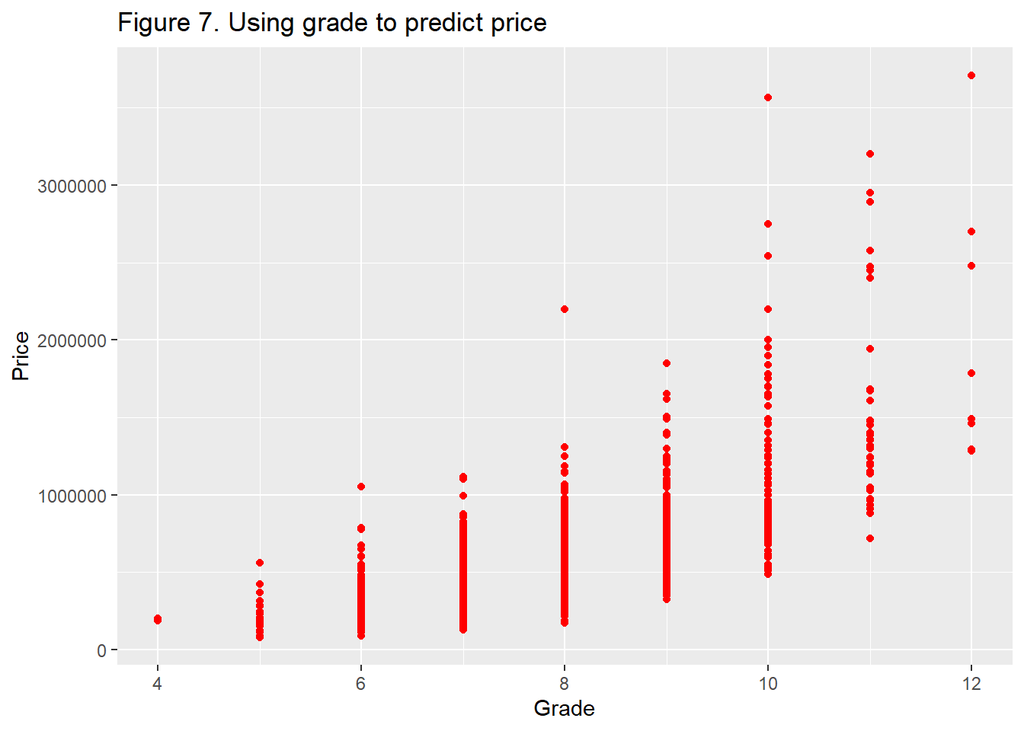

```r
ggplot(data = house2, aes(x = grade, y = price)) +
  geom_point(color = "red") +
  labs(title = "Figure 7. Using grade to predict price", y = "Price", x = "Grade")
```

Figure 7

This graph sees if grade can predict price. There is some upward trend as expected.

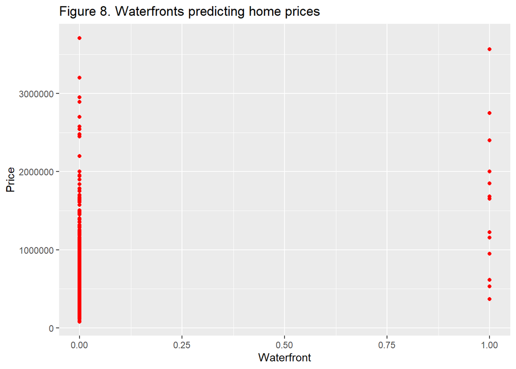

```r
options(scipen = 999)
ggplot(data = house2, aes(x = Waterfront, y = price)) +
  geom_point(color = "red") +
  labs(title = "Figure 8. Waterfronts predicting home prices", x = "Waterfront", y = "Price")
```

Figure 8

This graph shows that waterfront on average are more expensive. We will see if this comes into play later.

### Feature Engineering

# Creating The Model

## Preliminary Model

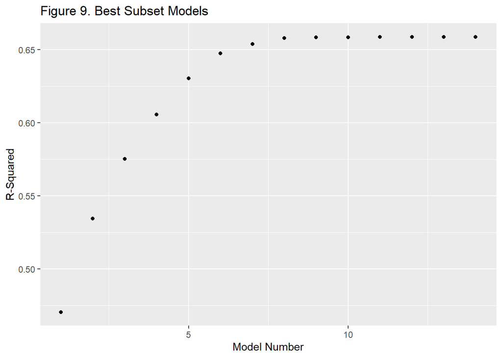

```r
set.seed(150)
training_rows <- sample(1:nrow(house2), size=floor(0.75*nrow(house2)))
Training <- house2[training_rows, ]
Testing <- house2[-training_rows, ]
#ggpairs(Training)

RMSE <- function(pred, obs){
  RMSE <- sqrt(mean((pred - obs)^2, na.rm = TRUE))
  return(RMSE)
}

library(olsrr)
modelAll<- lm(data = Training, price~.)
#summary(modelAll)

bestSubsetSelect <- ols_step_best_subset(modelAll)
#bestSubsetSelect
#choose the model based on how many variables you want


ggplot(data = bestSubsetSelect, aes(x = n, y = rsquare))+
  geom_point() +
  labs(title = "Figure 9. Best Subset Models", x= "Model Number", y = "R-Squared")
```

```r
bestSubsetModel <- lm(data = Training, price ~ grade + lat + view + bathrooms + yr_built + sqft_living15 + Waterfront)
#summary(bestSubsetModel)

testingPredictions <- predict.lm(bestSubsetModel,  newdata = Testing)
trainingPredictions <- predict.lm(bestSubsetModel, newdata = Training)

trainingRMSE = RMSE(trainingPredictions, Training$price)
testingRMSE = RMSE(testingPredictions, Testing$price)

library(car)
#vif(bestSubsetModel)
#ggpairs(bestSubsetModel)
```

### RMSE

The training RMSE for the best select model is 196970.8.

The testing RMSE for the best select model is 198970.3

### R Squared

The $r^2$ of this model is $0.654$

```r
set.seed(150)
mixedSubsetSelect <-ols_step_both_p(modelAll)
#mixedSubsetSelect

mixedSubsetModel <- lm(data = Training, price ~ grade + lat + view + bathrooms + yr_built + sqft_living15 + Waterfront + condition)
#summary(mixedSubsetModel)

testingPredictions1 <- predict.lm(mixedSubsetModel,  newdata = Testing)
trainingPredictions1 <- predict.lm(mixedSubsetModel, newdata = Training)

trainingRMSE1 = RMSE(trainingPredictions1, Training$price)
testingRMSE1 = RMSE(testingPredictions1, Testing$price)
```

## The Better Model

The second model is slightly better than the first so I will use this one.

$price = 132300.0*grade + 532200.0*lat + 65110.0*view + 98400.0*bathrooms$ $- 2757.0*yrBuilt + 75.37*sqft + 548400.0*waterfront + 22450.0*condition - 20820000.0$

This equation means that given the grade, lat, sqft, condition number of views, bathrooms, whether it has a waterfront or not, it increases the price of the house, while the year built actually decrease the closer to the present the house was built. This is likely due to the fact that the older houses are in the more desirable locations of Seattle.

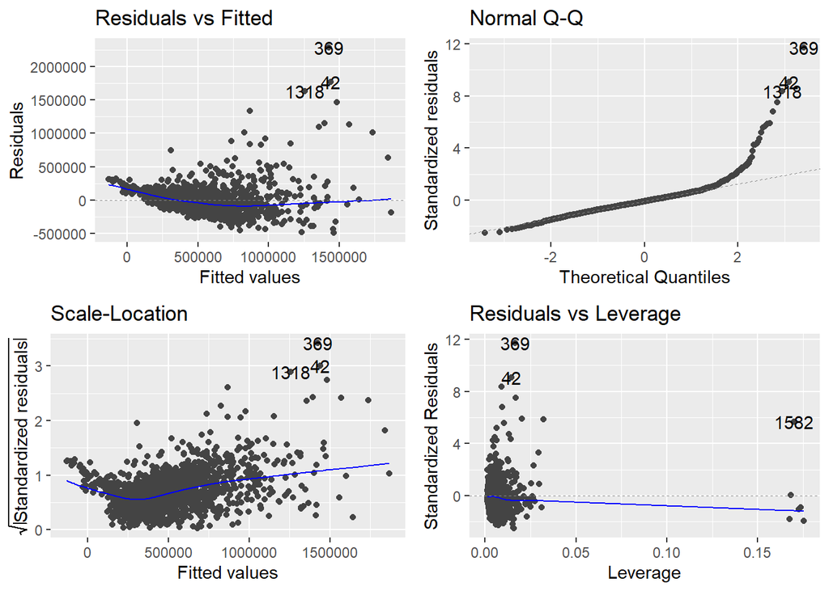

```r
library(ggfortify)
autoplot(mixedSubsetModel, title =  "Figure 10.")
```

### RMSE

The training RMSE for the best select model is 195831.5.

The testing RMSE for the best select model is 199898

### R Squared

The $r^2$ of this model is 0.658.

# Taking New Data

```r
houseSubset <- read.csv(file.choose())

housing1 <- houseSubset %>%
  select(price, bedrooms, bathrooms, sqft_living15, floors, waterfront, view, condition, grade, yr_built, yr_renovated, lat, long, houseID)

house2 <- housing1 %>%
  mutate(waterfront = ifelse(waterfront == TRUE, 1, 0),
         recentlyRenovated = ifelse(yr_renovated > 2010, 1, 0),
         familyHome = ifelse(bedrooms > 3, 1, 0)) %>%
  select(-yr_renovated)


set.seed(150)
training_rows <- sample(1:nrow(house2), size=floor(0.75*nrow(house2)))
Training <- house2[training_rows, ]
Testing <- house2[-training_rows, ]

mixedSubsetModel1 <- lm(data = Training, price ~ grade + lat + view + bathrooms + yr_built + sqft_living15 + waterfront + condition)
#summary(mixedSubsetModel1)
#ggpairs(mixedSubsetModel1)

testingPredictions1 <- predict.lm(mixedSubsetModel1,  newdata = Testing)
trainingPredictions1 <- predict.lm(mixedSubsetModel1, newdata = Training)

trainingRMSESubset = RMSE(trainingPredictions1, Training$price)
testingRMSESubset = RMSE(testingPredictions1, Testing$price)
```

## Old Model

Here we use the same model as we did before on a new dataset that was presented. These are the RMSE and $r^2$ values we get with this new data set using the same model as we did with the previous one.

### RMSE

The training RMSE for the model with the new data set is 341993.1.

The testing RMSE for the model with the new data set is 410337.1

### R Squared

0.712

### Equation

$year = 205900.0*grade + 412500.0*lat + 79510.0*view + 197400.0*bathrooms - 5334.0*yearBuilt$ $+ 190.8*sqft + 845500.0*waterfront + 42000.0*condition - 11050000.0$

```r
modelAll <- lm(data = Training, price~.)
#summary(modelAll)

newModel <- lm(data = Training, price~bathrooms+sqft_living15+view + waterfront + grade + yr_built + lat + floors + yr_built)
#summary(newModel)


bestSubsetSelect <- ols_step_both_p(modelAll)
#bestSubsetSelect

testingPredictions1 <- predict.lm(newModel,  newdata = Testing)
trainingPredictions1 <- predict.lm(newModel, newdata = Training)

trainingRMSENew = RMSE(trainingPredictions1, Training$price)
testingRMSENew = RMSE(testingPredictions1, Testing$price)
```

## New Model

### R Squared

The $r^2$ of this model is 0.720

### Equation

$price = 217700.0*bathrooms + 185.9*sqft + 76630.0*view +827300.0*waterfront$ $+ 215100.0*grade - 5310.0*yearBuilt + 356600.0*lat - 119700.0*floors - 8231000.0$

This model is very similar to the original model except for a few factors. The floors was added with a negative impact to the price, so more floors means that it decreases the price. This could be because typically houses with many floors lack overall area of the house which is used to increase the price. Condition was also not a good predictor for price in this model. It could be because this subset is likely all houses from similar communities. If the conditions are roughly the same given the houses then the data for condition is likely not a good predictor. We can see that waterfronts have a bigger impact on the price as well. This could be due to the fact that this is likely a more expensive subset of houses.

# Conclusion

Given the data, I was able to find multiple linear regression models for both datasets to help predict the price of houses in the Seattle area. The second dataset needed to use different predictors in order to predict the price. I had to use floors and get rid of the conditions factor.The RMSE was high only because the prices of the houses were all fairly high and varied quite a bit given the factors. The RMSE was much better for the first dataset than the second. This could be due to the fact that better predictors needed to be created for the second dataset. Overall, the models built are appropriate and can be used to predict the prices houses in the Seattle area.

# Bibliography

The 5 major factors that cause home prices to fluctuate. Newrez. (2021, October 8). Retrieved November 15, 2022, from https://www.newrez.com/blog/home-buying-selling/5-things-that-influence-home-prices-in-2021/

8 critical factors that influence a home’s value. Opendoor. (2022, August 24). Retrieved November 15, 2022, from https://www.opendoor.com/w/blog/factors-that-influence-home-value

Hayes, M. (2022, March 22). 5 factors that affect a home’s value. Experian. Retrieved November 15, 2022, from https://www.experian.com/blogs/ask-experian/factors-that-affect-home-value/